# Tutorial 2

**Credits**: Federico Ruggeri, Eleonora Mancini, Paolo Torroni

**Keywords**: Sparse/Dense Word embeddings, Embedding visualization

# Contact

For any doubt, question, issue or help, you can always contact us at the following email addresses:

Teaching Assistants:

- Federico Ruggeri -> federico.ruggeri6@unibo.it
- Eleonora Mancini -> e.mancini@unibo.it

Professor:

- Paolo Torroni -> p.torroni@unibo.it

## PART 0 ($\sim$5 mins)

- Downloading a **dataset**.
- Encoding a a **dataset**.

## PART I ($\sim$30 mins)

- Building a **vocabulary**.
- Building a **word-word co-occurrence matrix**.
- Defining a **similarity metric**: cosine similarity.
- Embedding **visualization** and **analysis** of their semantic properties.

## PART II ($\sim$30 mins)

- Loading pre-trained **dense** word embeddings: Word2Vec, GloVe, FastText.
- Checking **out-of-vocabulary** (OOV) terms.
- **Handling** OOV terms.

# Data

We will use the IMDB dataset first introduced in Tutorial 1.

- [**Stats**] A dataset of 50k sentences used for sentiment analysis: 25k with positive sentiment, 25k with negative one.
- [**Labels**] We ignore sentiment labels since we focus on learning a proper word embedding representation.

We start by **downloading** the dataset and **extract** it to a folder.

```python
url = "http://ai.stanford.edu/~amaas/data/sentiment/aclImdb_v1.tar.gz"
dataset_name = "aclImdb"

print(f"Current work directory: {Path.cwd()}")
dataset_folder = Path.cwd().joinpath("Datasets")

if not dataset_folder.exists():
    dataset_folder.mkdir(parents=True)

dataset_tar_path = dataset_folder.joinpath("Movies.tar.gz")
dataset_path = dataset_folder.joinpath(dataset_name)

if not dataset_tar_path.exists():
    download_dataset(dataset_tar_path, url)

if not dataset_path.exists():
    extract_dataset(dataset_tar_path, dataset_folder)
```

```
Current work directory: /home/fruggeri/Downloads
```

Let's inspect some major details of the dataset as follows.

```python
print(f"Dataset size: {df.shape}")
print(f"Dataset columns: {df.columns.values}")
print(f"Classes distribution:\n{df.sentiment.value_counts()}")
print(f"Some examples: {df.iloc[:5]}")
```

```
Dataset size: (50000, 5)
Dataset columns: ['file_id' 'score' 'sentiment' 'split' 'text']
Classes distribution:
sentiment
1    25000
0    25000
Name: count, dtype: int64
Some examples:   file_id  score  sentiment  split  \
0    2612     10          1  train
1    6812      7          1  train
2    8186     10          1  train
3   12429      7          1  train
4     584      8          1  train

                                                text
0  This is a film that was very well done. I had ...
1  This two-part TV mini-series isn't as good as ...
2  I love the Satan Pit!!! David Tennant is such ...
3  David Duchovny plays the lead role in this fil...
4  Excellent film dealing with the life of an old...
```

# PART I

- Building a **vocabulary**.
- Building a **word-word co-occurrence matrix**.
- Defining a **similarity metric**: cosine similarity.
- Embedding **visualization** and **analysis** of their semantic properties.

## 1. Building a vocabulary

We consider words as the atomic units for text representation: each word will be associated with a numeric representation.

At this point we can build the word vocabulary of our dataset. This information is the first step of any word embedding method: we need to know the set of atomic entities that build up our corpus.

**Definition**: a vocabulary is a collection of words occurring in a given dataset. More precisely, each word is recognized and assigned to an index.

**Example**: Suppose you have the given toy corpus $D$: { "the cat is on the table" }

The dataset is comprised of only one sentence: "the cat is on the table". The corresponding vocabulary (a possible one) will be:

V = {0: 'the', 1: 'cat', 2: 'is', 3: 'on', 4: 'table'}

In this case, indexing follows word order, but it is not mandatory!

### Note 1

The most important thing to remember is that the vocabulary **should always be the same one**.

$\rightarrow$ Thus, make sure that the vocabulary creation routine always returns the same result!

### Note 2

A vocabulary is **exclusively defined** by the tokenization step you define!

$\rightarrow$ Characters, sub-words, words are examples of granularity levels.

### 1.1 Text pre-processing

Before vocabulary creation, we have to do a little bit of **text pre-processing** so as to avoid spurious data.

$\rightarrow$ Data quality is one of the crucial factors that lead to better performance.

$\rightarrow$ Models, even state-of-the-art ones, hardly achieve satisfying results if the dataset is very noisy.

**Types of pre-processing**: there are a lot of pre-processing steps that we can consider, either general or quite task- specific.

- **Text to lower**: casing usually doesn't affect our task, but in some scenarios, such as part-of-speech tagging, it is crucial.
- **Replace special characters**: special characters are usually employed as variants of a single character like the spacing symbol ' '. In other cases (dates, etc..) special characters might have a specific meaning and should not be replaced.
- **Text stripping**: it is important to filter out extra spaces to avoid unwanted distinctions between identical words, such as 'apple' and ' apple '.

There are a lot of pre-processing techniques, such as number replacing, lemmatization, stemming, spell correction, acronyms merge and so on.

$\rightarrow$ If you are interested you can check [here](https://medium.com/swlh/text-normalization-7ecc8e084e31) and [here](https://www.kdnuggets.com/2019/04/text-preprocessing-nlp-machine-learning.html) some good blogs about the topic.

```python
REPLACE_BY_SPACE_RE = re.compile('[/(){}\[\]\|@,;]')
GOOD_SYMBOLS_RE = re.compile('[^0-9a-z #+_]')
try:
    STOPWORDS = set(stopwords.words('english'))
except LookupError:
    nltk.download('stopwords')
    STOPWORDS = set(stopwords.words('english'))
```

```python
def lower(text: str) -> str:
    """
    Transforms given text to lower case.
    """
    return text.lower()

def replace_special_characters(text: str) -> str:
    """
    Replaces special characters with spacing character
    """
    return REPLACE_BY_SPACE_RE.sub(' ', text)

def replace_br(text: str) -> str:
    """
    Replaces br characters
    """
    return text.replace('br', '')
```

```python
def filter_out_uncommon_symbols(text: str) -> str:
    """
    Removes any special character that is not
    in the good symbols list (check regular expression)
    """
    return GOOD_SYMBOLS_RE.sub('', text)

def remove_stopwords(text: str) -> str:
    return ' '.join([x for x in text.split()
                     if x and x not in STOPWORDS])

def strip_text(text: str) -> str:
    """
    Removes any left or right spacing
    (including carriage return) from text.
    """
    return text.strip()
```

```python
PREPROCESSING_PIPELINE = [
                          lower,
                          replace_special_characters,
                          replace_br,
                          filter_out_uncommon_symbols,
                          remove_stopwords,
                          strip_text
                          ]

def text_prepare(
    text: str,
    filter_methods: List[Callable[[str], str]] = None
) -> str:
    """
    Applies a list of pre-processing functions in sequence (reduce).
    Note that the order is important here!
    """
    filter_methods = filter_methods \
    if filter_methods is not None else PREPROCESSING_PIPELINE
    return reduce(lambda txt, f: f(txt), filter_methods, text)
```

```python
print('Pre-processing text...')
print()
print(f'[Debug] Before:\n{df.text.values[20][:203]}...')
print()

# Replace each sentence with its pre-processed version
df['text'] = df['text'].apply(lambda txt: text_prepare(txt))

print(f'[Debug] After:\n{df.text.values[20][:203]}...')
print()
print("Pre-processing completed!")
```

```
Pre-processing text...

[Debug] Before:
I was shocked and surprised by the negative reviews I saw on the web, I thought Cinderella 2 (as well as 3) is a very cute and funny sequel for everyone - kids and adults...like me, I am 22 years old.<br...

[Debug] After:
shocked surprised negative reviews saw web thought cinderella 2 well 3 cute funny sequel everyone kids adultslike 22 years old also find informative film shows lessons true following heart thought great ...

Pre-processing completed!
```

### 1.2 Vocabulary Creation

Since the text has been pre-processed, space splitting should work correctly.

We proceed on building the vocabulary and perform some sanity checks.

$\rightarrow$ Bare in mind that some packages offers tools for automatic vocabulary creation, such as Keras (check [keras.preprocessing.text.Tokenizer](https://www.tensorflow.org/api_docs/python/tf/keras/preprocessing/text/Tokenizer)).

```python
def build_vocabulary(
    df: pd.DataFrame
) -> (Dict[int, str], Dict[str, int], List[str]):
    """
    Given a dataset, builds the corresponding word vocabulary.

    :param df: dataset from which we want to build
    the word vocabulary (pandas.DataFrame)
    :return:
      - word vocabulary: vocabulary index to word
      - inverse word vocabulary: word to vocabulary index
      - word listing: set of unique terms that build up the vocabulary
    """
    idx_to_word = OrderedDict()
    word_to_idx = OrderedDict()

    curr_idx = 0
    for sentence in tqdm(df.text.values):
        tokens = sentence.split()
        for token in tokens:
            if token not in word_to_idx:
                word_to_idx[token] = curr_idx
                idx_to_word[curr_idx] = token
                curr_idx += 1

    word_listing = list(idx_to_word.values())
    return idx_to_word, word_to_idx, word_listing
```

```python
idx_to_word, word_to_idx, word_listing = build_vocabulary(df)
print(f'[Debug] Index -> Word vocabulary size: {len(idx_to_word)}')
print(f'[Debug] Word -> Index vocabulary size: {len(word_to_idx)}')

some_words = [(idx_to_word[idx], idx) for idx in np.arange(10) + 1]
print(f'[Debug] Some words: {some_words}')
```

```
[Debug] Index -> Word vocabulary size: 152534
[Debug] Word -> Index vocabulary size: 152534
[Debug] Some words: [('well', 1), ('done', 2), ('heard', 3), ('mixed', 4), ('reviews', 5), ('production', 6), ('waiting', 7), ('release', 8), ('cheers', 9), ('director', 10)]
```

```python
def evaluate_vocabulary(
    idx_to_word: Dict[int, str],
    word_to_idx: Dict[str, int],
    word_listing: List[str],
    df: pd.DataFrame,
    check_default_size: bool = False
):
    assert len(idx_to_word) == len(word_to_idx)
    assert len(idx_to_word) == len(word_listing)

    for i in tqdm(range(0, len(idx_to_word))):
        assert idx_to_word[i] in word_to_idx
        assert word_to_idx[idx_to_word[i]] == i

    _, _, first_word_listing = build_vocabulary(df)
    _, _, second_word_listing = build_vocabulary(df)
    assert first_word_listing == second_word_listing

    toy_df = pd.DataFrame.from_dict({
        'text': ["all that glitters is not gold",
                 "all in all i like this assignment"]
    })
    _, _, toy_word_listing = build_vocabulary(toy_df)
    toy_valid_vocabulary = set(' '.join(toy_df.text.values).split())
    assert set(toy_word_listing) == toy_valid_vocabulary
```

```python
print("Vocabulary evaluation...")
evaluate_vocabulary(idx_to_word, word_to_idx, word_listing, df)
print("Evaluation completed!")
```

```
Vocabulary evaluation...
```

```
Evaluation completed!
```

### Note

Define **intermediary tests** for your code in order to inspect data and to assess the correctness of your code!

$\rightarrow$ You don't want to **re-run** huge and time-consuming experiments due to early pipeline errors!

### 1.3 Saving the vocabulary

Generally speaking, it is a good idea to save the dictionary in clear format.

$\rightarrow$ In this way you can quickly check for errors or useful words.

In this case, we will save the vocabulary dictionary in **JSON format**.

#### Homework 📖

Spend some time at checking the built vocabulary!

In many tasks (e.g., sequential tagging, embedding analysis, etc...), the way text is tokenized is crucial!

## 2. Sparse embeddings

Working with text inherently requires a numerical conversion step, known as **embedding**.

**Bag-of-Words (BoW)**

1. Count the occurrence of each word in a given corpus
2. Build a word co-occurrence matrix: useful to identify the most common terms in each given document.

This type of reasoning is directly related to **how meaning is assigned to words**.

$\rightarrow$ In particular, it is the environment enclosing a word that gives a specific meaning to it.

$\rightarrow$ Thus, we look for numerical encoding methods that reflect such point of view.

### 2.1 A quick simplification

Since the dataset is quite large, the co-occurrence matrix construction may take a while or may require efficient solutions.

For the purpose of this tutorial, we can rely on a **small slice** of the dataset.

$\rightarrow$ Nonetheless, feel free to work with the whole dataset! Suggestions on how to handle this scenario are given below when required.

```python
# This type of slicing is not mandatory,
# but it is sufficient to our purposes
np.random.seed(42)

random_indexes = np.random.choice(np.arange(df.shape[0]),
                                  size=1000,
                                  replace=False)

df = df.iloc[random_indexes]
print(f'New dataset size: {df.shape}')
idx_to_word, word_to_idx, word_listing = build_vocabulary(df)
```

```
New dataset size: (1000, 5)
```

### 2.2 Building the Co-occurence Matrix

For each word in the vocabulary we count the number of times each other word appears within the same context window.

Let's define the simplest version of a **co-occurrence matrix** based on word counting.

### Small dataset case

You should have a vocabulary size that we can afford in terms of memory demand.

$\rightarrow$ You can easily instantiate the co-occurrence matrix and populate it iteratively.

### Large dataset case

We have to work with sparse matrices due to the high vocabulary size and to the low amount of non-zero word counts.

$\rightarrow$ The [Scipy package](https://docs.scipy.org/doc/scipy/reference/sparse.html) allows us to easily define sparse matrices that can be converted ot numpy arrays.

**Suggestion**: The simplest way to build the co-occurrence matrix is via an incremental approach:

1. Loop through dataset sentences
2. Split into words
3. Count co-occurrences within the given window frame.

```python
def co_occurrence_count(df: pd.DataFrame,
                        idx_to_word: Dict[int, str],
                        word_to_idx: Dict[str, int],
                        window_size: int = 4) -> np.ndarray:
    """
    Builds word-word co-occurrence matrix based on word counts.

    :return
      - co_occurrence symmetric matrix of size |V| x |V|
    """
    vocab_size = len(idx_to_word)
    co_occurrence_matrix = np.zeros((vocab_size, vocab_size),
                                    dtype=np.float32)
    for sentence in tqdm(df.text.values):
        tokens = sentence.split()
        for pos, token in enumerate(tokens):
            start = max(0, pos - window_size)
            end = min(pos + window_size + 1, len(tokens))

            first_word_index = word_to_idx[token]
            for pos2 in range(start, end):
                if pos2 != pos:
                    second_token = tokens[pos2]
                    second_word_index = word_to_idx[second_token]
                    co_occurrence_matrix[first_word_index,
                                         second_word_index] += 1
    return co_occurrence_matrix
```

```python
# Clean RAM before re-running this code snippet
# to avoid possible session crash
if 'co_occurrence_matrix' in globals():
    del co_occurrence_matrix
    gc.collect()
    time.sleep(10.)     # Give colab some time

print("Building co-occurrence count matrix.. (it may take a while..)")
co_occurrence_matrix = co_occurrence_count(df,
                                           idx_to_word,
                                           word_to_idx,
                                           window_size=4)
print("Building completed!")
```

```
Building co-occurrence count matrix.. (it may take a while..)
```

```
Building completed!
```

### 2.3 Embedding Visualization

The next step is to visualize our sparse word embeddings in a lower dimensional space (2D) in order to have an idea of the meaning attributed to each word.

**How?** We will explore SVD, t-SNE methods, and Umap, without delving into technical details since they are not arguments of this NLP course.

**SVD Memo**: SVD stands for **Singular Value Decomposition** and is a kind of generalized **Principal Components Analysis** (PCA) and focuses on selecting the top **k** principal components. For more info, [here](https://davetang.org/file/Singular_Value_Decomposition_Tutorial.pdf) you can find a brief tutorial.

**t-SNE Memo**: t-SNE stands for **t-Distributed Stochastic Neighbour Embedding** and is an unsupervised non-linear technique.

- It preserves small pairwise distance (or local similarities), whereas PCA aims to preserve large pairwise distances in order to maximize variance.
- The basic idea of t-SNE is to compute a similarity measure between a pair of instances both at high and low dimensional space and optimize these two similarities via a cost function.
- Properly using t-SNE is a bit tricky, a well recommended reading is one of the [author's blog](https://lvdmaaten.github.io/tsne/).

**UMAP Memo**: UMAP stands for **Uniform Manifold Approximation and Projection for Dimensionality Reduction** and is an unsupervised non-linear technique like t-SNE.

- **Faster** than t-SNE
- **More accurate** than t-SNE in terms of data's global structure preservation
- Informally constructs a high-dimensional graph representation of the data and then optimizes a low-dimensional graph to be as structurally similar as possibile
- Check this [blog](https://pair-code.github.io/understanding-umap/) if you are interested!

#### Homework 📖

Play with the **window size** and check if there are some notable differences.

Generally:

- Small window size $\rightarrow$ reflects syntactic properties.
- Large window size $\rightarrow$ captures semantic ones.

```python
def reduce_umap(embeddings: np.ndarray) -> np.ndarray:
    """
    Applies UMAP dimensionality reduction.
    """
    umap_emb = umap.UMAP(n_components=2, metric='cosine')
    reduced = umap_emb.fit_transform(embeddings)

    return reduced
```

```python
# Feel free to play with word_annotations argument!
# Check the saved dictionary!
def run_visualization(method_name: str,
                      words_list: List[str],
                      word_to_idx: Dict[str, int],
                      co_occurrence_matrix):
    method_name = method_name.lower().strip()
    method_map = {
        'svd': reduce_SVD,
        'tsne': reduce_tSNE,
        'umap': reduce_umap
    }

    if method_name not in method_map:
        raise RuntimeError(f'Invalid method name! Got {method_name}.')

    reduced = method_map[method_name](co_occurrence_matrix)
    visualize_embeddings(reduced, words_list, word_to_idx)
```

```
Annotating words: ['good', 'love', 'beautiful']
```

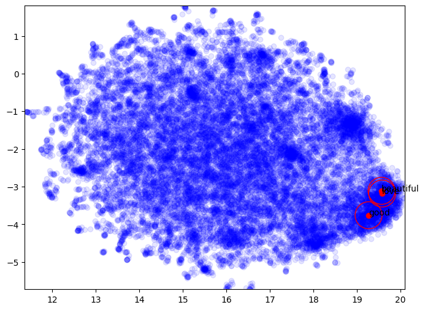

```python
run_visualization('umap', ['good', 'love', 'beautiful'],
                  word_to_idx, co_occurrence_matrix)
```

#### Homework 📖

Play with different dimension reduction techniques.

Note that these techniques are very sensitive to some of their hyper-parameters!

### 2.4 Embedding properties

Visualization can give us a rough idea of how word embeddings are organized and if some semantic properties are reflected in the numerical dimensional space.

$\rightarrow$ For example, are synonyms close together? Ideally, if the dataset is big enough, we should see similar vector embeddings since synonyms usually have similar contexts.

##### How to do that?

We could highlight target words in the visualization step and check if our expectations are met. For instance, synonyms should be close together.

**However**, this method is rather **inaccurate** and **time-consuming** (dimensionality reduction is not a perfect mapping).

$\rightarrow$ We need some sort of similarity metric that is independent of the vector dimensionality.

### 2.5 Cosine Similarity

We want to measure how two word vectors are far apart.

#### Naive Method

A naive solution would involve computing the dot product of the two vectors.

However, this metric will give higher similarity either to longer vectors or to vectors that have higher counts.

#### Cosine Similarity

A better metric is **cosine similarity** which is just a normalized dot product.

\begin{align} s(p, q) = \frac{p \, \cdot \, q}{||p|| \, \cdot \, ||q||} \end{align}

where $s(p, q) \in [-1, 1] $, since it computes the cosine of the angle between the two vectors.

Intuitively, we are bringing vectors down to the d-dimensional unit sphere (d is the vocab size) and then computing their distance (in 2D space we will have a circle).

```python
from sklearn.metrics.pairwise import cosine_similarity as sk_cs

def cosine_similarity(p: np.ndarray,
                      q: np.ndarray,
                      transpose_p: bool = False,
                      transpose_q: bool = False) -> np.ndarray:
    """
    Computes the cosine similarity of two d-dimensional matrices

    :param p: d-dimensional vector of shape (p_samples, d)
    :param q: d-dimensional vector of shape (q_samples, d)
    :param transpose_p: whether to transpose p or not
    :param transpose_q: whether to transpose q or not

    :return
        - cosine similarity matrix S of shape (p_samples, q_samples)
          where S[i, j] = s(p[i], q[j])
    """
    if len(p.shape) == 1:
        p = p.reshape(1, -1)
    if len(q.shape) == 1:
        q = q.reshape(1, -1)

    return sk_cs(p.T if transpose_p else p, q.T if transpose_q else q)

similarity_matrix = cosine_similarity(co_occurrence_matrix,
                                      co_occurrence_matrix)
```

### 2.6 [Let's play] Analogies, Bias, Synonyms and Antonyms

Let's look for some words and provide a possible explanation of achieved results according to cosine similarity metric.

- Synonym pair: (w1, w2) such that w1 and w2 are synonyms
- Antonyms pair: (w1, w2) such that w1 and w2 are antonyms
- Synonym-Antonym triplet: (w1, w2, w3) such that w1 and w2 are synonyms and w1 and w3 are antonyms

#### Analogy

Another useful property to check is analogy resolution via word vectors.

In particular, we might want to check if analogies such "man : king == woman : x" bring results like "x = queen".

In order to do so, we first need to define a ranking function that returns the top $K$ most similar words of a given word vector.

$\rightarrow$ We might not want to be too much restrictive and play with $K \ge 1$.

```python
show_similarity_for_nary(['film', 'movie'],
                         similarity_matrix,
                         word_to_idx,
                         idx_to_word)
```

```
Similarity values:
           film     movie
film   1.000000  0.874242
movie  0.874242  1.000000
```

```python
show_similarity_for_nary(['good', 'bad'],
                         similarity_matrix,
                         word_to_idx,
                         idx_to_word)
```

```
Similarity values:
          good       bad
good  1.000000  0.784855
bad   0.784855  1.000000
```

```python
show_similarity_for_nary(['good', 'well', 'bad'],
                         similarity_matrix,
                         word_to_idx,
                         idx_to_word)
```

```
Similarity values:
          good      well       bad
good  1.000000  0.803706  0.784855
well  0.803706  1.000000  0.668593
bad   0.784855  0.668593  1.000000
```

Positive and negative listing can be defined accordingly to a given analogy

#### Example

```
man : king :: woman : x

positive_listing = ['king', 'woman']
negative_listing = ['man']
```

This is equivalent to: compute king - man + woman, and then find the most similar candidate.

```python
# tv : episodes :: film : x
# masterpiece : superb :: x : tragic
top_K_words,\
top_K_values = get_top_K_word_ranking(co_occurrence_matrix,
                                      idx_to_word,
                                      word_to_idx,
                                      ['episodes', 'film'],
                                      ['tv'],
                                      10)
print(f'Top K words: {top_K_words}')
print(f'Top K values: {top_K_values}')
```

```
Top K words: ['movie', 'one', 'also', 'story', 'would', 'way', 'like', 'see', 'think', 'good']
Top K values: [0.851024   0.81515384 0.79548836 0.7926224  0.7839537  0.76730263
 0.7661221  0.75843847 0.7542812  0.75335056]
```

#### Homework 📖

Take some time to play with different analogies.

**How?** Check the vocabulary and related tokens frequency!

# PART II

- Loading pre-trained **dense** word embeddings: Word2Vec, GloVe, FastText.
- Checking **out-of-vocabulary** (OOV) terms.
- **Handling** OOV terms.

## 1. Dense embeddings

Until now we've worked with sparse embedding methods, which lead to high dimensional word embeddings (dimension equal to $|V|$).

The **main drawback** of such approach is that words belong to separate dimensions.

$\rightarrow$ We need to have a large corpus available to check if two words have similar contexts.

#### Dense Embedding Technique

A dense representation is also convenient from a machine learning point of view:

- **Fewer parameters** to learn and, thus, models are less prone to overfitting.
- Words do not belong to separate dimensions anymore and semantic relationships are easily modelled.

### 1.1 Working with a pre-trained model

The first step consists in choosing and downloading a pre-trained embedding model.

For the purpose of this assignment, we limit to classic models, such as Word2Vec, GloVe and FastText.

Furthermore, some pre-trained embedding model versions may be quite resource demanding, depending on the embedding dimension and on the vocabulary size.

$\rightarrow$ We recommend sticking to low dimensional spaces (50, 100, 200) to avoid being stuck waiting for too much time.

### A Brief Recap

For a full list of available embeddings models, please check [here](https://github.com/RaRe-Technologies/gensim-data).

- **Word2Vec**: the first example of dense word encoding. There are two well-known strategies:
  - Continuous Bag-of-words (CBoW): context words are used to predict a target word.
  - Skip-gram: a target word is used to predict its own context.
- **GloVe**: it is another techniques that tries to encoded global semantic properties based on the co-occurrence matrix. Conversely, word2vec exploits local information.
- **Fasttext**: an extension of word2vec where words are defined as character n-grams. It works very well with rare words contrarily to Word2Vec and GloVe.

```python
# Modify these variables as you wish!
# Glove -> 50, 100, 200, 300
# Word2Vec -> 300
# Fasttext -> 300
embedding_model = load_embedding_model(model_type="glove",
                                       embedding_dimension=50)
```

#### Homework 📖

Play with different embedding models and embedding sizes.

Compare the achieved visualizations.

### 1.2 Out of vocabulary (OOV) words

Before evaluating pre-trained dense word embeddings, it is good practice to check if the model is consistent with our dataset.

$\rightarrow$ We check the number of out-of-vocabulary (OOV) terms.

If the OOV amount is negligible, we can just keep going. On the other hand, we might want to handle OOV terms by assigning them a specific word vector.

**Which one?** One common practice is to assign a **random vector**, since the embedding model will be part of a deep learning model and, thus, word vectors might be trained during the learning process.

Even if that is the case, we can assign an embedding that is more meaningful rather than a random one.

$\rightarrow$ We can identify the word embedding of an OOV term as the **mean of its neighbour word embeddings**.

```python
oov_terms = check_OOV_terms(embedding_model, word_listing)
oov_percentage = float(len(oov_terms)) * 100 / len(word_listing)
print(f"Total OOV terms: {len(oov_terms)} ({oov_percentage:.2f}%)")
```

```
Total OOV terms: 2477 (12.74%)
```

### 1.3 Handling OOV words

Now we proceed on building the embedding matrix, while handling OOV terms at the same time.

```python
# Testing
embedding_dimension = 50
embedding_matrix = build_embedding_matrix(embedding_model,
                                          embedding_dimension,
                                          word_to_idx,
                                          len(word_to_idx),
                                          oov_terms)
print(f"Embedding matrix shape: {embedding_matrix.shape}")
```

```
Embedding matrix shape: (19442, 50)
```

### 1.4 Embedding visualization (cont'd)

We are now ready to visualize pre-trained word embeddings!

```
Annotating words: ['good', 'love', 'beautiful']
```

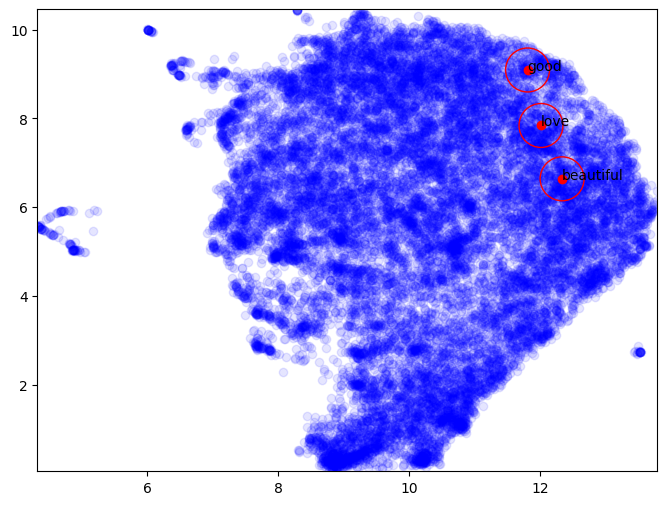

```python
visualize_embeddings(reduced_embedding_umap,
                     ['good', 'love', 'beautiful'],
                     word_to_idx)
```

### 1.5 [Let's play!] Embedding properties (cont'd)

Let's consider some previous examples for quick comparison.

```python
top_K_words,\
top_K_values = get_top_K_word_ranking(embedding_matrix,
                                      idx_to_word,
                                      word_to_idx,
                                      ['episodes', 'film'],
                                      ['tv'],
                                      10)
print(f'Top K words: {top_K_words}')
print(f'Top K values: {top_K_values}')
```

```
Top K words: ['adaptation', 'episode', 'novel', 'films', 'sequel', 'novels', 'screenplay', 'soundtrack', 'cameo', 'drama']
Top K values: [0.78791964 0.7871996  0.7586306  0.74662924 0.73375267 0.7320131
 0.7301122  0.72881866 0.70862806 0.69585866]
```

#### Homework 📖

Compare word embedding analysis between sparse and dense word embeddings.

# Takeway Messages

#### Teaching

Your TA should be quite thirsty and tired at this point, make sure they are okay even though you didn't understand a single word of their "English". Possibly, offer them a beer 💞.

#### Dense vs Sparse Embeddings

Dense word embeddings are very cool w.r.t. to sparse ones. However, we've just explored fixed embedding models: each word has its own embedding vector independently of the current context.

#### Out-of-vocabulary Terms

OOV terms are everywhere, when we should worry about them? Have a look at pre-trained embedding models if they are suitable to your domain to drastically reduce this issue.